# final_project

Santhosh reddy Mallikireddy

05/12/2019

```r
library(caret)
library(factoextra)
library(hrbrthemes)
library(GGally)
library(viridis)
```

1. a : purchase behavior (including brand loyalty) variables we choose for purchase behavior are “No. of Brands”,“Brand Runs”,“Total Volume”,“No. of Trans”,“Value”,“Trans / Brand Runs”,“Vol/Tran”,“Avg. Price”,“Others 999”,“max_Brand_ind”

```r
set.seed(123)
library(readr)
BathSoap <- read_csv("BathSoap.csv")
```

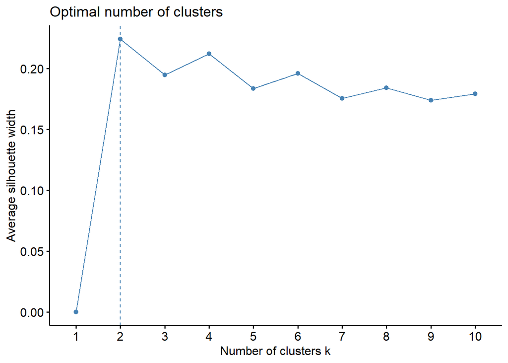

```r
#View(BathSoap)
r1<-BathSoap[,23:30]
BathSoap$max_Brand_ind<-as.numeric(apply(r1,1,max))
#here we are considering the max value out of the 8 brands given.
BS1<-BathSoap[,c(12:19,31,47)]
#View(BS1)
data1<-as.data.frame(scale(BS1)) # scaling the data
# Elbow chart to estimate the optimal K
fviz_nbclust(data1,kmeans,method = "silhouette")
```

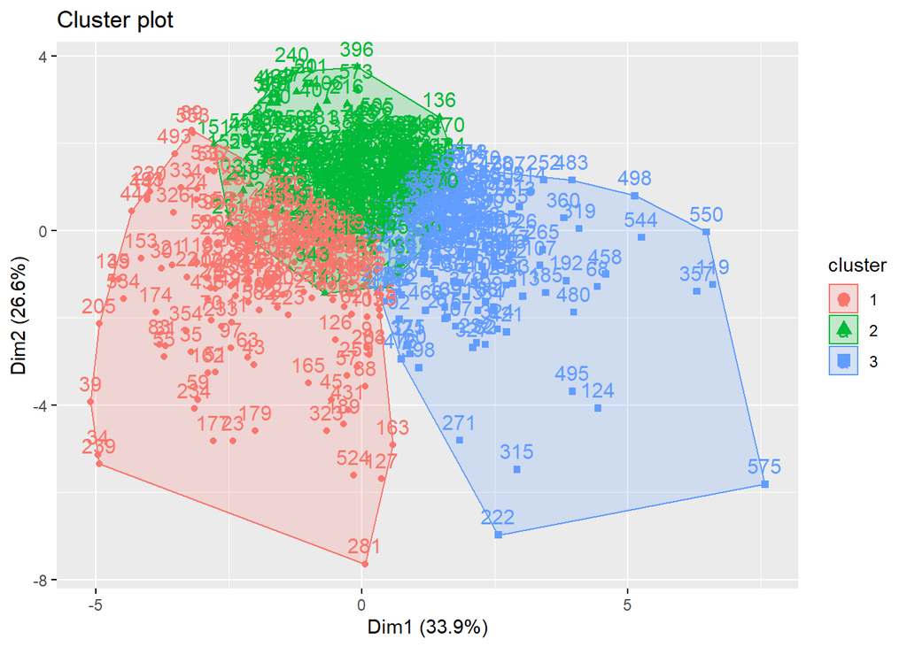

```r
# Choosing the optimal K as 3 and forming 3 clusters

model1<-kmeans(data1,3,nstart=50)
# Visualizing the clusters
fviz_cluster(model1,data1)
```

```r
result1<-as.data.frame(cbind(1:nrow(model1$centers),model1$centers))
result1$V1<-as.factor(result1$V1)
# Characteristics of the cluster
result1
```

```
##   V1 No. of Brands Brand Runs Total Volume No. of  Trans       Value
## 1  1    -0.4934603 -0.7236194    0.1846318    -0.4114518 -0.05446008
## 2  2    -0.2759333 -0.2156513   -0.5323647    -0.4155637 -0.45499157
## 3  3     0.9507367  1.0993197    0.6359753     1.0821389  0.76730922
##   Trans / Brand Runs   Vol/Tran Avg. Price Others 999 max_Brand_ind
## 1          0.6077360  0.5853534 -0.4587115 -1.1290154     1.2402467
## 2         -0.2473209 -0.2735992  0.2283229  0.5987318    -0.5323700
## 3         -0.2548053 -0.1902088  0.1273427  0.2560612    -0.4768636
```

```r
model1$size
```

```
## [1] 175 259 166
```

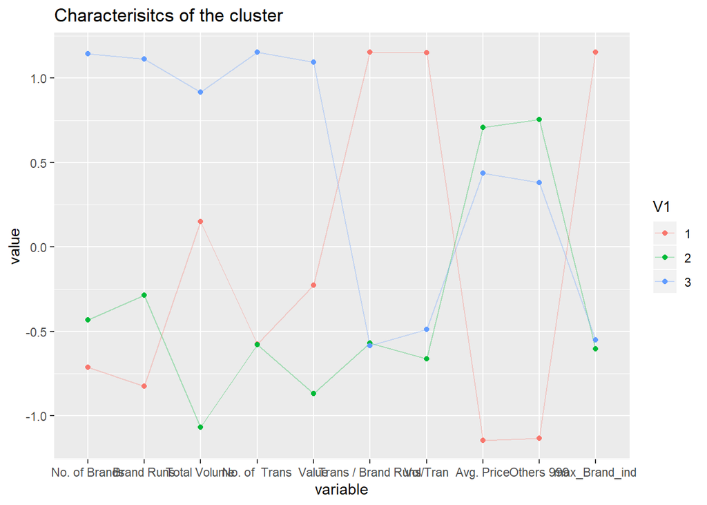

```r
# Parallel plot to visualize the cluster.
ggparcoord(result1,
           columns = 2:ncol(result1), groupColumn = 1,
           showPoints = TRUE,
           title = "Characterisitcs of the cluster",
           alphaLines = 0.3
)
```

Comment: As we can see cluster 2 and cluster 3 have similar characteristics for variables trans/brand runs(low) , Vol/trans(low) and avg price(high) and are less loyal to brands where as cluster 1 has trans/brand runs(high) , Vol/trans(high)and avg price(low) with high brand loyality.we can say that clusters with less avg value and more trans/brand runs are more loyal to specific brands.

2. basis for purchase variables that are included in basis for purchase are “Pur Vol No Promo - %” “Pur Vol Promo 6 %”,“Pur Vol Other Promo %”,“Pr Cat 1”,“Pr Cat 2”,“Pr Cat 3”,“Pr Cat 4”,“max_prop”

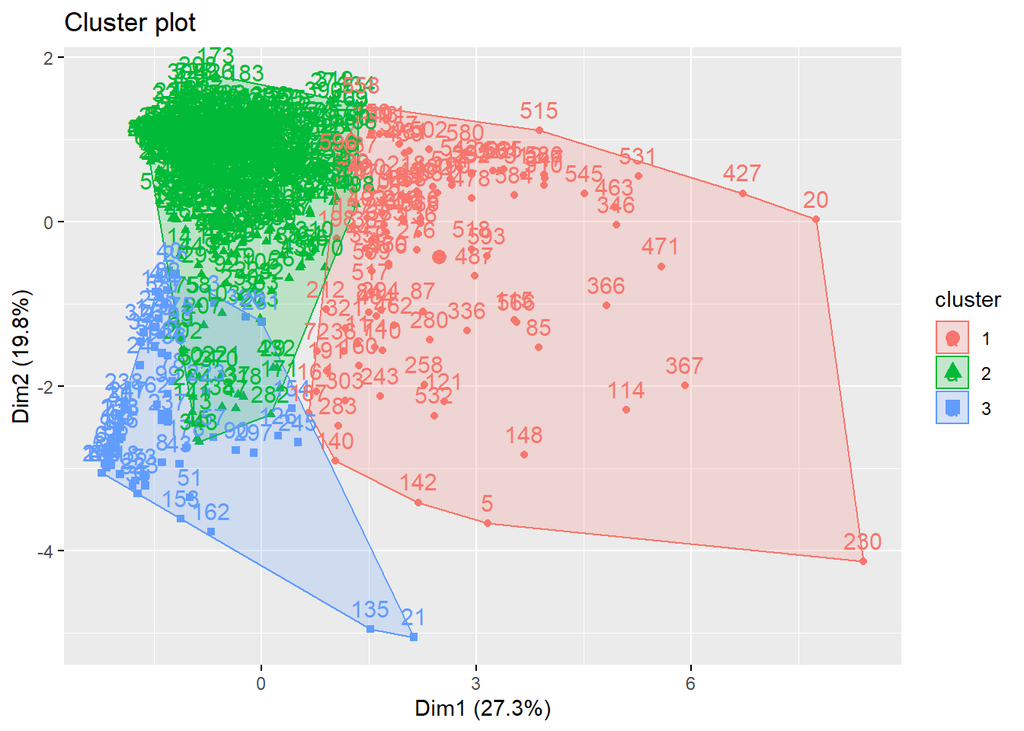

```r
r2<-BathSoap[,36:46]
BathSoap$max_prop_no<-as.numeric(apply(r2,1,which.max))
BathSoap$max_prop<-as.numeric(apply(r2,1,max))
#most people seemed to be responding to only few of the propositions, so we can the max value from all the propositons.
BS2<-BathSoap[,c(20:22,32:35,49)]
#View(BS2)
data2<-as.data.frame(scale(BS2)) # scaling the data

# Choosing the optimal K as 3 and forming 3 clusters
model2<-kmeans(data2,3,nstart=50)

# Visualizing the clusters
fviz_cluster(model2,data2)
```

```r
result2<-as.data.frame(cbind(1:nrow(model2$centers),model2$centers))
result2$V1<-as.factor(result2$V1)
# Characteristics of the cluster
result2
```

```
##   V1 Pur Vol No Promo - % Pur Vol Promo 6 % Pur Vol Other Promo %
## 1  1           -1.6753944         1.5351429             0.7942665
## 2  2            0.3591417        -0.2937761            -0.2159952
## 3  3            0.3313992        -0.5291617             0.1350441
##      Pr Cat 1   Pr Cat 2   Pr Cat 3    Pr Cat 4    max_prop
## 1  0.28747617 -0.2902592 -0.3105394  0.48441543 -0.38550796
## 2  0.05478764  0.2612340 -0.3221158 -0.05513508 -0.01753293
## 3 -0.80050906 -1.2138944  2.5443612 -0.40695235  0.71615570
```

```r
model2$size
```

```
## [1] 105 428  67
```

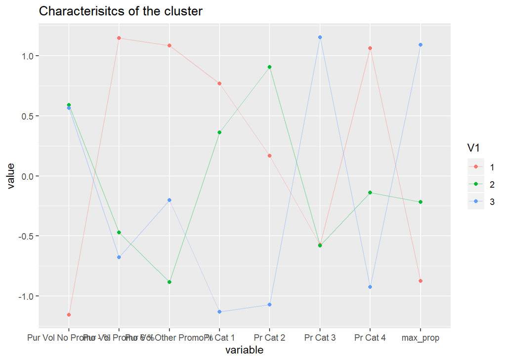

```r
# Parallel plot to visualize the cluster.
ggparcoord(result2,
           columns = 2:ncol(result2), groupColumn = 1,
           showPoints = TRUE,
           title = "Characterisitcs of the cluster",
           alphaLines = 0.3
)
```

c)both purchase behavior and basis of purchase variables include are “No. of Brands”,“Brand Runs”,“Total Volume”,“No. of Trans”,“Value”,“Trans / Brand Runs”,“Vol/Tran”,“Avg. Price”,“Others 999”,“max_Brand_ind”,“Pur Vol No Promo - %” “Pur Vol Promo 6 %”,“Pur Vol Other Promo %”,“Pr Cat 1”,“Pr Cat 2”,“Pr Cat 3”,“Pr Cat 4”,“max_prop”

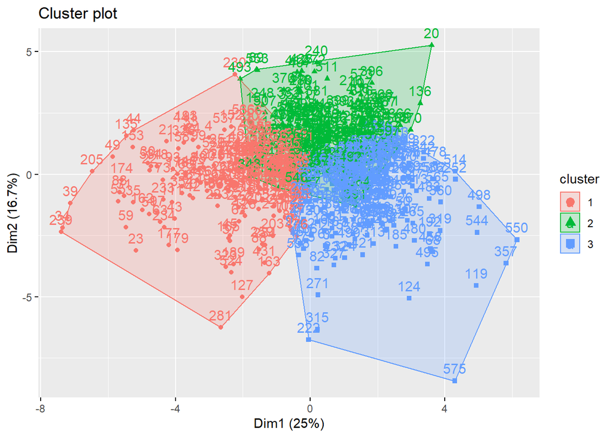

```r
BS3<-BathSoap[,c(12:22,31:35,47,49)]
#View(BS3)
data3<-as.data.frame(scale(BS3)) # scaling the data

# Choosing the optimal K as 3 and forming 3 clusters
model3<-kmeans(data3,3,nstart=50)

# Visualizing the clusters
fviz_cluster(model3,data3)
```

```r
result3<-as.data.frame(cbind(1:nrow(model3$centers),model3$centers))
result3$V1<-as.factor(result3$V1)
# Characteristics of the cluster
result3
```

```
##   V1 No. of Brands Brand Runs Total Volume No. of  Trans      Value
## 1  1    -0.4415878 -0.6533245    0.1379542    -0.4095943 -0.1290146
## 2  2    -0.5355990 -0.3679096   -0.5358290    -0.4942869 -0.4202521
## 3  3     0.8928878  0.9385645    0.3545583     0.8259381  0.4985096
##   Trans / Brand Runs   Vol/Tran Avg. Price Pur Vol No Promo - %
## 1          0.4803077  0.5675279 -0.6092892            0.3042684
## 2         -0.1864074 -0.2675783  0.4436238           -0.1393148
## 3         -0.2783812 -0.2862997  0.1664992           -0.1572252
##   Pur Vol Promo 6 % Pur Vol Other Promo % Others 999    Pr Cat 1
## 1        -0.4076960            0.01953425 -0.9518018 -0.68904124
## 2         0.1431833            0.04128407  0.7454741  0.62463663
## 3         0.2498496           -0.05534672  0.2128274  0.07752608
##     Pr Cat 2   Pr Cat 3   Pr Cat 4 max_Brand_ind   max_prop
## 1  0.1901929  0.6757571 -0.2438239     1.0569076  0.7061380
## 2 -0.4730066 -0.4261012  0.4469815    -0.5871606  0.1451538
## 3  0.2494164 -0.2440511 -0.1761328    -0.4531279 -0.7869507
```

```r
model3$size
```

```
## [1] 197 191 212
```

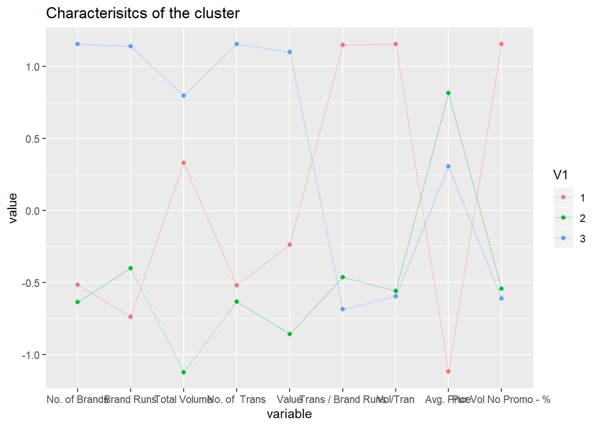

```r
# Parallel plot to visualize the cluster.
ggparcoord(result3,
           columns = 2:10, groupColumn = 1,
           showPoints = TRUE,
           title = "Characterisitcs of the cluster",
           alphaLines = 0.3
)
```

```r
ggparcoord(result3,
           columns = 11:19, groupColumn = 1,
           showPoints = TRUE,
           title = "Characterisitcs of the cluster",
           alphaLines = 0.3
)
```

[figure not shown]

Comment: Cluster 1 with low “AVg.price” and high “Pur Vol No Promo-%” has high max_brand and max_prop. clusters (2, 3) has high “Avg.price” and low “Pur Vol No Promo-%” and has less loyal to specific brands.

Q2):choosing the best segmentation out of the three approaches:

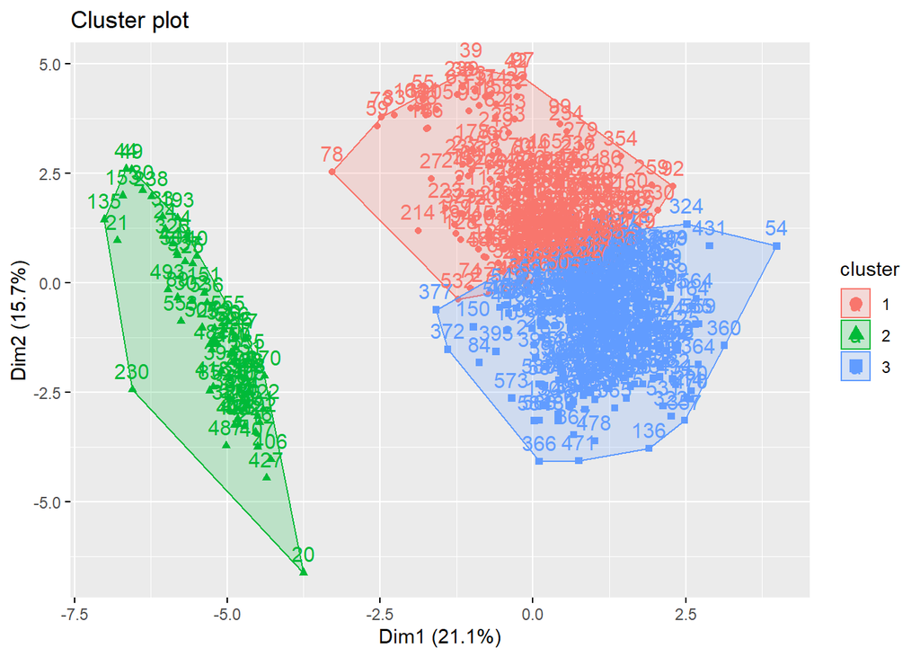

```r
#BEST MODEL
R<-BathSoap[,23:30]
BathSoap$Loyality<-as.numeric(apply(R,1,which.max))
BS<-BathSoap[,c(2:11,20:22,31:35,47,49,50)]
#View(BS)
data<-as.data.frame(scale(BS)) # scaling the data

# Choosing the optimal K as 3 and forming 3 clusters
model<-kmeans(data,3,nstart=50)

# Visualizing the clusters
fviz_cluster(model,data)
```